# Measuring the Return of Football Player Investment on Team Performance

Candidate Number: 37942

January 15 2025

**Prompt:** 2

**ChatGPT/AI disclosure statement:** I utilized ChatGPT to check spelling and assist in creating vectors for merging my data. This was particularly important because team names were inconsistently formatted and appeared in different languages across my sources. To standardize them, I assigned a unique ID to each team, and ChatGPT streamlined the process by efficiently aiding in the assignment of these IDs.

### 1. Research scope and rationale

Football clubs invest heavily in player transfers to strengthen their teams, making it essential to understand how these investments relate to team performance.

This report compiles two key data sources for future analysis. First, I gather player transaction data from **transfermarkt.com** for the 36 clubs in the UEFA Champions League since 1997, providing details on transfer spending and financial strategies. Second, I collect team performance data from **clubelo.com**, which uses ELO ratings to measure team strength based on match results.

By presenting these datasets, this report sets the foundation for understanding the connection between financial investments on players and team performance in elite European football.

### 2. Web scraping transaction data

**Transfermarkt** is a leading platform for football transaction data, offering crucial information about player stats, market values, and club transfers It serves as a primary resource for analyzing trends in the football transfer market.

Here is an example of how transfer data is presented on the platform, showcasing Manchester City’s “altas” (purchases) and “bajas” (sales) for the current season.

[figure not shown]

To retrieve the transaction history of every Champions League team, I followed next steps:

#### 2.1 Extract the names and unique IDs of all 36 teams from the Champions League page on Transfermarkt

```r
# Setup

current_directory <- getwd()
inputs <- file.path(current_directory, "inputs")
outputs <- file.path(current_directory, "outputs")

if (!dir.exists(inputs)) {
  dir.create(inputs)}
if (!dir.exists(outputs)) {
  dir.create(outputs)}

images <- file.path(inputs, "images")
if (!dir.exists(images)) {
  dir.create(images)}

packages_needed <- c("rvest", "tidyverse", "httr", "kableExtra", "ggplot2", "ggimage", "readr")

for (package in packages_needed) {
  if (!requireNamespace(package, quietly = TRUE)) {
    install.packages(package)
  }
}
```

```r
library(rvest)
library(tidyverse)
library(httr)
library(kableExtra)
library(ggplot2)
library(readr)


url <- "https://www.transfermarkt.es/uefa-champions-league/teilnehmer/pokalwettbewerb/CL/saison_id/2024"
page <- read_html(url)
href_links <- page %>%
  html_nodes("a") %>%
  html_attr("href")

#Filter just the club-page links
team_data <- unique(grep("verein", href_links, value = TRUE))

# Separate names and ids
team_names <- gsub("/(.*)/startseite/verein/[0-9]+", "\\1", team_data)
team_ids <- as.double(gsub(".*/verein/([0-9]+)", "\\1", team_data))

# Create a data frame with team info
team_info <- data.frame(
  name = team_names,
  id = team_ids,
  stringsAsFactors = FALSE
)
```

#### 2.2 Construct the URL of the transaction data for each team and clean the team names for better readability

```r
team_info$team_transfer_link <- paste0("https://www.transfermarkt.es/", team_info$name,
                                       "/alletransfers/verein/", team_info$id)

# Replace the transfer-market names with the real names of the teams for better legibility
team_info <- team_info %>%
  mutate(
    name = str_replace_all(name, "-", " "),
    name = str_to_title(name),
    name = str_replace_all(name, "\\bFc\\b", "FC") # FC means Football Club and it needs to be in uppercase
  )
```

#### 2.3 Set up parameters to automate the search process

```r
current_season <- as.numeric(format(Sys.Date(), "%Y")) - 1 # Set the current season
first_season <- 1997 # The starting season from which data will be retrieved
number_tables <- (current_season - first_season) * 2  #Each year has a sales and a purchases table

# Create labels for each season
seasons <- vector("character", length = current_season - first_season + 1)
for (year in first_season:current_season) {
  seasons[year - first_season + 1] <- paste0(year,"/", year + 1)
}
```

#### 2.4 Function to extract and clean data, focusing on the total money spent on player purchases and earned through sales

```r
process_team_url <- function(team_url, team_name, team_ids, number_tables, seasons) {

  Sys.sleep(runif(1, min = 1, max = 5)) # Wait to make a new request

  page <- read_html(team_url)
  tables <- html_table(page)

  # Limit the tables to the number of seasons
  tables <- tables[1:min(length(tables), number_tables)]
  values <- character(length = length(tables))

  # Extract the last value of each table (sales/purchases)
  for (i in seq_along(tables)) {
    table <- tables[[i]]

    # Check if the table has data
    if (nrow(table) > 0 && ncol(table) > 0) {
      value <- as.character(table[nrow(table), ncol(table)])
    } else {
      value <- NA  # If the table is empty, set as NA
    }
    values[i] <- value
  }

  # Clean the extracted values
  clean_values <- gsub(",", ".", values)
  clean_values <- gsub(" mil €", "", clean_values)
  clean_values <- gsub(" mill\\. €", "", clean_values)
  clean_values <- gsub(" €", "", clean_values)
  numeric_values <- as.numeric(clean_values)

  # Adjust values to millions of euros
  numeric_values[grepl("mil ", values)] <- numeric_values[grepl("mil ", values)] / 1000
  numeric_values[!grepl("mil ", values) & !grepl("mill.", values)] <-
    numeric_values[!grepl("mil ", values) & !grepl("mill.", values)] / 1000000


  # Separate into purchases, sales, and balance
  purchases <- numeric_values[seq(1, length(numeric_values), by = 2)]  # Odd indices
  sales <- numeric_values[seq(2, length(numeric_values), by = 2)]  # Even indices
  balance <- sales - purchases

  # Create a data frame with the information
team_transaction <- data.frame(
    Team = team_name,
    ID = team_ids,
    Season = rev(seasons)[1:length(purchases)],
    Purchases = purchases,
    Sales = sales,
    Balance = balance
  )
  return(team_transaction)
}
```

#### 2.5 Iterate to extract information for all 36 teams

```r
 # This  code chunk is currently set to eval = FALSE. To start scraping, change it to eval = TRUE

 #Only execute the scraping process if it is necessary

if (!file.exists("outputs/all_teams_transaction.csv")) {

        all_teams_transaction <- vector("list", length = length(team_info$team_transfer_link) * number_tables)

        # Loop through team information to process URLs and store results
        for (i in seq_along(team_info$team_transfer_link)) {
          all_teams_transaction[[i]] <- process_team_url(
            team_url = team_info$team_transfer_link[i],
            team_name = team_info$name[i],
            team_ids = team_info$id[i],
            number_tables = number_tables,
            seasons = seasons
          )
        }

        # Combine all data frames from the list into one
        all_teams_transaction <- dplyr::bind_rows(all_teams_transaction)

        #Store the output as csv
        write.csv(all_teams_transaction, "outputs/all_teams_transaction.csv", row.names = FALSE)
        write.table(all_teams_transaction, "outputs/all_teams_transaction.txt", sep = "\t",
                    row.names = FALSE, quote = FALSE, fileEncoding = "UTF-8")

}
```

The following table presents team transaction data, where each row represents a team’s financial activity during a specific season. The columns include the team’s name, an ID number, the season, total expenditures on player purchases, total revenue from player sales, and the resulting balance. All monetary values are in millions of euros.

```r
all_teams_transaction <- read.csv("outputs/all_teams_transaction.csv")
kable(head(all_teams_transaction), caption = "Table 1: First observations of team transaction data")
```

Table 1: First observations of team transaction data

| Team | ID | Season | Purchases | Sales | Balance |
| --- | --- | --- | --- | --- | --- |
| Real Madrid | 418 | 2024/2025 | 49.0 | 16.00 | -33.00 |
| Real Madrid | 418 | 2023/2024 | 139.5 | 7.00 | -132.50 |
| Real Madrid | 418 | 2022/2023 | 80.0 | 92.15 | 12.15 |
| Real Madrid | 418 | 2021/2022 | 31.0 | 78.00 | 47.00 |
| Real Madrid | 418 | 2020/2021 | 0.0 | 108.20 | 108.20 |
| Real Madrid | 418 | 2019/2020 | 361.3 | 136.80 | -224.50 |

### 3. Team Performance via ELO Ratings

ELO ratings measure team performance by accounting for match results, opponent strength, and game significance. This dynamic system captures changes in team strength over time, influenced by transfers and management.

Used widely in research, ELO allows cross-league and cross-era comparisons. The **clubelo.com** API offers access to historical ELO ratings, enabling analysis of performance trends linked to financial investments.

#### 3.1 Retrieve the URL required to query data for each Champions League team from the API

```r
url <- "http://clubelo.com/UCL"
page <- read_html(url)
href_links_elo <- page %>%
  html_nodes("a") %>%
  html_attr("href")

#Filter only the champions league teams
start_index <- grep("^/UCL$", href_links_elo)
end_index <- grep("^/UEL$", href_links_elo)
filtered_links <- href_links_elo[(start_index + 1):(end_index - 1)]

base_url <- "http://api.clubelo.com"
urls <- paste0(base_url, filtered_links)
```

#### 3.2 Set the parameters to initiate the searches

```r
start <- as.Date("1997-08-01") # Each european football season starts in August
end <- as.Date("2024-12-31")
all_clubs_data <- list()
```

#### 3.3 Iterate through each URL to retrieve the ELO data

```r
# This code chunk is currently set to eval = FALSE. To start scraping, change it to eval = TRUE
# Only execute the scraping process if it is necessary

if (!file.exists("outputs/all_teams_elo.csv")) {

    for (i in seq_along(urls)) {

      Sys.sleep(runif(1, min = 1, max = 4)) # Wait to make a new request

      # Read data for each club
      club_data <- read_csv(urls[i], show_col_types = FALSE)

      # Filter data by date range
      club_filtered <- club_data %>%
        filter(From >= start & To <= end)

      # Add the club name to the dataset
      club_name <- sub("^/", "", filtered_links[i])
      club_filtered$Club <- club_name

      # Append the filtered data to the list
      all_clubs_data[[i]] <- club_filtered
    }

    # Combine all data frames at once
    all_teams_elo <- bind_rows(all_clubs_data)

    rm(club_data, club_filtered, all_clubs_data)

    #Store the output as csv
    write.csv(all_teams_elo, "outputs/all_teams_elo.csv", row.names = FALSE)
    write.table(all_teams_elo, "outputs/all_teams_elo.txt", sep = "\t", row.names = FALSE, quote = FALSE, fileEncoding = "UTF-8")

  }
```

The following table displays the team ELO data, where each row corresponds to an update after a specific match. Columns include the team’s rank, name, country, league level, ELO rating, and the start and end dates for the given ELO score period.

```r
all_teams_elo <- read.csv("outputs/all_teams_elo.csv")
kable(head(all_teams_elo), caption = "Table 2: First observations of team ELO data")
```

Table 2: First observations of team ELO data

| Rank | Club | Country | Level | Elo | From | To |
| --- | --- | --- | --- | --- | --- | --- |
| 39 | Liverpool | ENG | 1 | 1721.084 | 1997-08-03 | 1997-08-05 |
| 37 | Liverpool | ENG | 1 | 1721.084 | 1997-08-06 | 1997-08-09 |
| 37 | Liverpool | ENG | 1 | 1720.381 | 1997-08-10 | 1997-08-11 |
| 38 | Liverpool | ENG | 1 | 1720.381 | 1997-08-12 | 1997-08-13 |
| 43 | Liverpool | ENG | 1 | 1707.226 | 1997-08-14 | 1997-08-16 |
| 44 | Liverpool | ENG | 1 | 1707.226 | 1997-08-17 | 1997-08-23 |

### 4. Data Processing and Transformation

#### 4.1 Get the season average ELO for each team

```r
# Convert From and To to Date type
all_teams_elo$From <- as.Date(all_teams_elo$From)
all_teams_elo$To <- as.Date(all_teams_elo$To)

# Calculate the average Elo per season
average_season_elo <- all_teams_elo %>%
  mutate(
  Season = ifelse(
  as.numeric(format(To, "%m")) >= 8,  # If the "To" month is August or later
  paste0(format(To, "%Y"), "/", as.numeric(format(To, "%Y")) + 1),  # Season ends in current year and starts in previous year
  paste0(as.numeric(format(To, "%Y")) - 1, "/", format(To, "%Y"))  # If before August, season ends in current year but starts previous year
    )
  ) %>%
  group_by(Club, Season, Country) %>%
  summarise(avg_elo = mean(Elo, na.rm = TRUE), .groups = "drop")
```

#### 4.2 Merge the transaction and performance data

Since the team names in the transaction and performance datasets do not exactly match, I provided ChatGPT with the unique team names from both datasets and asked it to generate the corresponding IDs for the ELO dataset.

###### The following lines of code were generated by AI/ChatGPT

```r
ids <- c("Arsenal" = 11, "AstonVilla" = 405, "Atalanta" = 800, "Atletico" = 13, "Barcelona" = 131,
         "Bayern" = 27, "Benfica" = 294, "Bologna" = 1025, "Brest" = 3911, "Brugge" = 2282, "Celtic" = 371,
         "CrvenaZvezda" = 159, "DinamoZagreb" = 419, "Dortmund" = 16, "Feyenoord" = 234, "Girona" = 12321,
         "Inter" = 46, "Juventus" = 506, "Leverkusen" = 15, "Lille" = 1082, "Liverpool" = 31,  "ManCity" = 281,
         "Milan" = 1, "Monaco" = 162, "PSV" = 383, "ParisSG" = 583, "RBLeipzig" = 23826, "RealMadrid" = 418,
         "Salzburg" = 409, "Shakhtar" = 660, "SlovanBratislava" = 540, "SpartaPraha" = 197, "Sporting" = 336,
         "SturmGraz" = 122, "Stuttgart" = 79, "YoungBoys" = 452)
```

With the ID vector, we can now merge the transaction and performance data:

```r
average_season_elo <- average_season_elo %>%
  mutate(ID = ids[Club])

teams_table <- all_teams_transaction %>%
  left_join(average_season_elo, by = c("ID", "Season")) %>%
  select(-Club) %>%   # Drop the 'Club' variable since it is the same as the 'Team' one
  drop_na()
```

#### 4.3 Calculate the annual change in ELO

```r
teams_table <- teams_table %>%
  mutate(year = as.numeric(substr(Season, 1, 4))) %>%  # Extract the first 4 digits and convert to get the year
  arrange(Team, year) %>%
  group_by(Team) %>%
  mutate(elo_change = round(avg_elo - lag(avg_elo),2)) %>%  # Calculate the difference in ELO
  ungroup()%>%
  drop_na(elo_change)
```

```r
teams_table <- teams_table %>%
  group_by(Team) %>%
  arrange(year) %>%
  mutate(
    total_purchases = cumsum(Purchases),
    total_sales = cumsum(Sales),
    total_balance = cumsum(Balance)
  ) %>%
  select(-Season) %>% #Since we have the year variable, we no longer need it
  ungroup()  %>%
  mutate(log_purchases = ifelse(Sales == 0, NA, round(log(Sales * 1e6), 2)))

kable(head(teams_table), caption = "Table 3: Merged data after transformations")
```

Table 3: Merged data after transformations

| Team | ID | Purchases | Sales | Balance | Country | avg_elo | year | elo_change | total_purchases | total_sales | total_balance | log_purchases |
| --- | --- | --- | --- | --- | --- | --- | --- | --- | --- | --- | --- | --- |
| Ac Sparta Prag | 197 | 0.70 | 0.85 | 0.15 | CZE | 1689.069 | 1999 | 29.77 | 0.70 | 0.85 | 0.15 | 13.65 |
| As Monaco | 162 | 50.49 | 13.60 | -36.89 | FRA | 1814.827 | 1999 | 16.54 | 50.49 | 13.60 | -36.89 | 16.43 |
| Aston Villa | 405 | 9.90 | 6.07 | -3.83 | ENG | 1690.583 | 1999 | -10.27 | 9.90 | 6.07 | -3.83 | 15.62 |
| Atalanta Bergamo | 800 | 0.00 | 0.00 | 0.00 | ITA | 1666.057 | 1999 | 4.29 | 0.00 | 0.00 | 0.00 | NA |
| Atletico Madrid | 13 | 24.50 | 38.50 | 14.00 | ESP | 1727.040 | 1999 | -38.86 | 24.50 | 38.50 | 14.00 | 17.47 |
| Bayer 04 Leverkusen | 15 | 24.55 | 18.75 | -5.80 | GER | 1809.881 | 1999 | -2.68 | 24.55 | 18.75 | -5.80 | 16.75 |

```r
write.csv(teams_table, "outputs/teams_table.csv", row.names = FALSE)
write.table(teams_table, "outputs/teams_table.txt", sep = "\t", row.names = FALSE, quote = FALSE, fileEncoding = "UTF-8")
```

#### 4.5 The team logos were scraped, downloaded, and the path to each logo was then added to the Elo dataset for visualization purposes

```r
page_url <- "https://www.uefa.com/uefachampionsleague/clubs/"
html_content <- read_html(page_url)
group_sections <- html_content %>%
  html_nodes(".teams-overview_group")

# Filter the section that corresponds to the "League phase"
league_phase_group <- group_sections %>%
  .[html_nodes(., "h2") %>% html_text(trim = TRUE) == "League phase"]

# Extract team names and logo URLs
team_badges <- league_phase_group %>%
  html_nodes(".team-wrap") %>%
  lapply(function(item) {
    list(
      team_name = item %>% html_node("span[slot='primary']") %>% html_text(trim = TRUE),
      logo_url = item %>% html_node("pk-badge") %>% html_attr("src")
    )
  }) %>%
  do.call(rbind.data.frame, .)

# Remove duplicate teams based on their names
team_badges <- team_badges %>%
  distinct(team_name, .keep_all = TRUE)
colnames(team_badges) <- c("Team_Name", "Logo_URL")
```

I asked ChatGPT to give me the IDs of the badges dataset based on the transactions dataset.

###### The following lines of code were generated by AI/ChatGPT

```r
team_ids <- c(
  "Arsenal" = 11, "Aston Villa" = 405, "Atalanta" = 800, "Atleti" = 13,
  "B. Dortmund" = 16, "Barcelona" = 131, "Bayern München" = 27, "Benfica" = 294,
  "Bologna" = 1025, "Brest" = 3911, "Celtic" = 371, "Club Brugge" = 2282,
  "Crvena Zvezda" = 159, "Feyenoord" = 234, "Girona" = 12321, "GNK Dinamo" = 419,
  "Inter" = 46, "Juventus" = 506, "Leipzig" = 23826, "Leverkusen" = 15,
  "Lille" = 1082, "Liverpool" = 31, "Man City" = 281, "Milan" = 1, "Monaco" = 162,
  "Paris" = 583, "PSV" = 383, "Real Madrid" = 418, "S. Bratislava" = 540,
  "Salzburg" = 409, "Shakhtar" = 660, "Sparta Praha" = 197, "Sporting CP" = 336,
  "Sturm Graz" = 122, "Stuttgart" = 79, "Young Boys" = 452
)
```

```r
# Add team IDs to the badges data
team_badges$team_id <- as.integer(team_ids[team_badges$Team_Name])

# Define image save path
save_dir <- "inputs/images/"

# Check if the folder is not empty
if (length(list.files(save_dir)) == 0) {
  # Download images if the folder is empty
  for (i in 1:nrow(team_badges)) {
    download.file(team_badges$Logo_URL[i], file.path(save_dir, paste0(team_badges$team_id[i], ".png")))
  }
}

# Add a "Badge" column to the dataset by appending ".png" to the "ID" column,
# it will be used to visualize team logos later

teams_table <- teams_table %>%
  mutate(Badge = file.path(save_dir, paste0(ID, ".png")))
```

### 5. Analysis of team transactions and performance

#### 5.1 Transactions by teams per season

[figure not shown]

```r
# Filter the top 12 teams with the highest elo
team_purchases_summary <- teams_table %>%
  arrange(desc(avg_elo)) %>%
  distinct(Team, .keep_all = TRUE) %>%
  head(12)

# Filter data from 2014 onward
team_purchases_series_top_12 <- teams_table %>%
  filter(Team %in% team_purchases_summary$Team & year >= 2014)

# Get the max value of Purchases and round it to the nearest multiple of 100
max_purchase <- max(team_purchases_series_top_12$Purchases, na.rm = TRUE)
y_max <- ceiling(max_purchase / 100) * 100


top_teams <- ggplot(team_purchases_series_top_12, aes(x = year, y = Purchases)) +
  geom_line(color = "grey", size = 0.5) +
  geom_point(size = 0.001, color = "black") +
  labs(
    title = "Investment in Players per Season by the Top 12 Teams in the Champions League",
    y = "Total Purchases (in Euros)",
    x = "Season"
  ) +
  theme_minimal() +
  theme(
    axis.title = element_text(size = 10, face = "bold"),
    axis.text = element_text(size = 7),
    plot.title = element_text(size = 12, face = "bold", hjust = 0.5),
    panel.border = element_rect(color = "black", fill = NA, size = 0.5),
    panel.grid.major.y = element_line(color = "gray85", size = 0.5, linetype = "dashed"),
    panel.grid.major.x = element_line(color = "gray85", size = 0.5, linetype = "dashed"),
    panel.grid.minor = element_blank(),
  ) +
  ggimage::geom_image(
    aes(x = year, y = Purchases, image = Badge),
    size = 0.10,
    inherit.aes = FALSE
  ) +
  facet_wrap(~ Team) +  # Create individual plots for each team
  scale_x_continuous(breaks = seq(min(team_purchases_series_top_12$year),
                                  max(team_purchases_series_top_12$year), by = 2)) +
  scale_y_continuous(limits = c(0, y_max), breaks = seq(0, y_max, by = 100))


top_teams
```

```r
ggsave("outputs/top_teams.jpg", plot = top_teams )
```

#### 5.2 Delving into the relationship between transactions and team perfomance

Scatter plots below show how purchases, financial balance, and cumulative purchases correlate with each team’s average ELO rating.

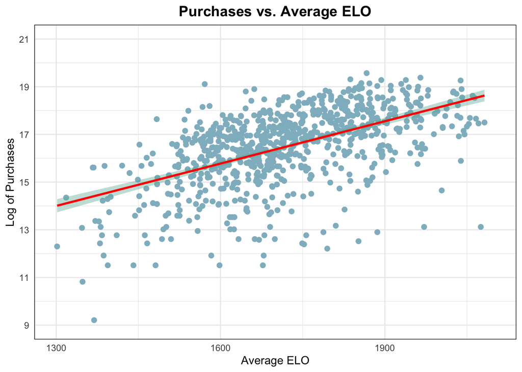

```r
# First, I configured the common settings for the graphs.

plot_theme <-
  theme_minimal() +
  theme(
    legend.position = NULL,
    plot.title = element_text(hjust = 0.5, size = 14, face = "bold"),
    panel.border = element_rect(color = "black", fill = NA, size = 0.5)
  )


# ELO vs log(purchases) Graph

scatter_1 <- ggplot(teams_table, aes(x = avg_elo, y = log_purchases)) +
  geom_point(size = 2, color = "#8FBAC8") +
   scale_y_continuous(
        limits = c(9, 21),
        breaks = seq(9, 21, by = 2)) +
     scale_x_continuous(
        limits = c(1300, 2100),
        breaks = seq(1300, 2100, by = 300)) +
  geom_smooth(method=lm , color="red", fill="#69b3a2", se=TRUE) +
  labs(
    title = "Purchases vs. Average ELO",
    x = "Average ELO",
    y = "Log of Purchases"
  ) +
plot_theme

scatter_1
```

```r
ggsave("outputs/scatter_1.jpg", plot = scatter_1)
```

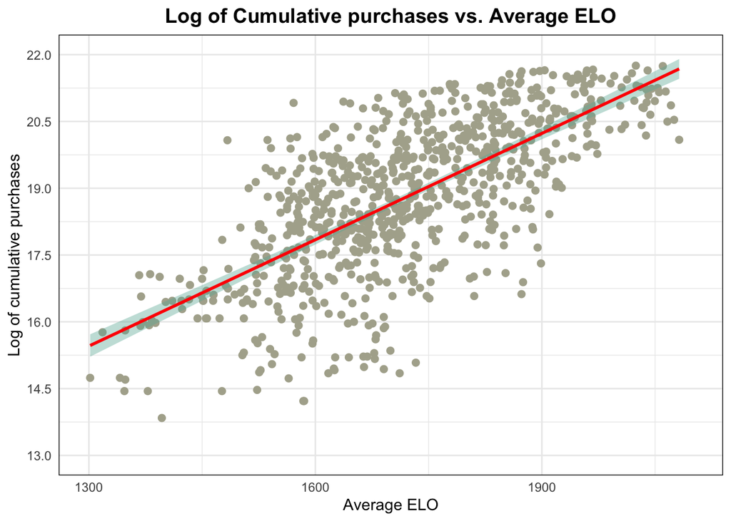

```r
# ELO vs log(cumulative_purchases) Graph
# I filtered for total_purchases greater than one to enhance the readability of the graph.

scatter_2 <- ggplot(teams_table %>% filter(total_purchases > 1), aes(x = avg_elo, y = log(total_purchases * 1000000))) +
  geom_point(size = 2, color = "#AFAE9B") +
  scale_y_continuous(
    limits = c(13, 22),
    breaks = seq(13, 22, by = 1.5)) +
  scale_x_continuous(
    limits = c(1300, 2100),
    breaks = seq(1300, 2100, by = 300)) +
   geom_smooth(method=lm , color="red", fill="#69b3a2", se=TRUE) +
  labs(
    title = "Log of Cumulative purchases vs. Average ELO",
    x = "Average ELO",
    y = "Log of cumulative purchases"
  ) +
plot_theme

scatter_2
```

```r
ggsave("outputs/scatter_2.jpg", plot = scatter_2)
```

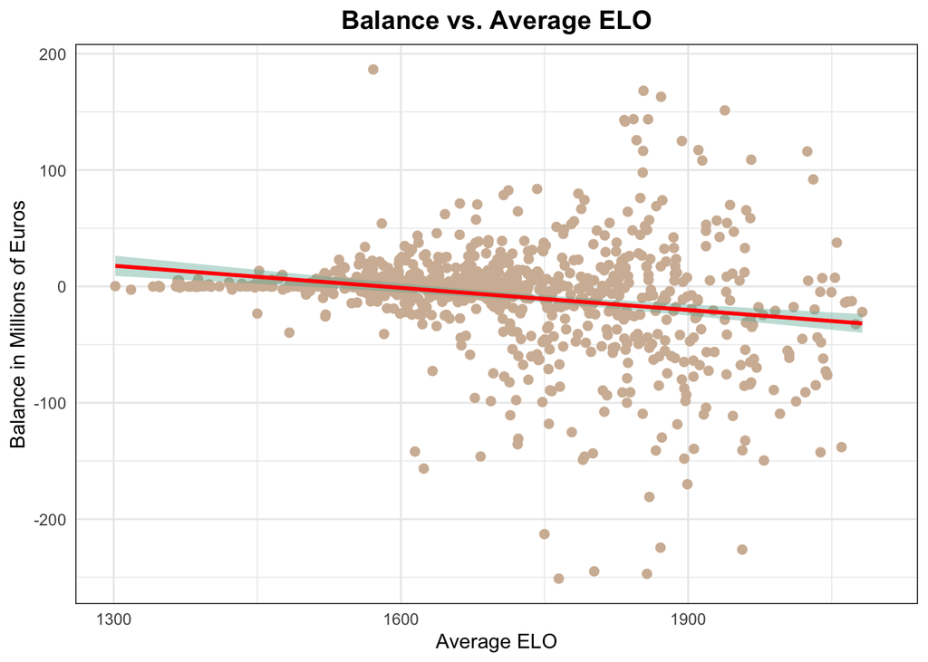

```r
# ELO vs Balance Graph

scatter_3 <- ggplot(teams_table, aes(x = avg_elo, y = Balance)) +
  geom_point(size = 2, color = "#D2B9A3") +
     scale_x_continuous(
        limits = c(1300, 2100),
        breaks = seq(1300, 2100, by = 300)) +
   geom_smooth(method=lm , color="red", fill="#69b3a2", se=TRUE) +
  labs(
    title = "Balance vs. Average ELO",
    x = "Average ELO",
    y = "Balance in Millions of Euros"
  ) +
plot_theme

scatter_3
```

```r
ggsave("outputs/scatter_3.jpg", plot = scatter_3)
```

#### 5.3 Calculate correlations between purchases and change in ELO

```r
# Create a dataset with the correlations between purchases and the change of elo

correlations <- teams_table %>%
  arrange(Team, year) %>%
  group_by(Team) %>%
  summarise(
    Purchases_t0 = cor(avg_elo, log_purchases, use = "complete.obs"),
    Purchases_t1 = cor(avg_elo, lag(log_purchases, 1), use = "complete.obs"),
    Purchases_t2 = cor(avg_elo, lag(log_purchases, 2), use = "complete.obs"),
    Purchases_t3 = cor(avg_elo, lag(log_purchases, 3), use = "complete.obs"),
    .groups = "drop"
  ) %>%
  pivot_longer(
    cols = starts_with("Purchases_"),
    names_to = "Lag",
    values_to = "Correlation"
  )

write.csv(correlations, "outputs/correlations.csv", row.names = FALSE)
write.table(correlations, "outputs/correlations.txt", sep = "\t", row.names = FALSE, quote = FALSE, fileEncoding = "UTF-8")
```

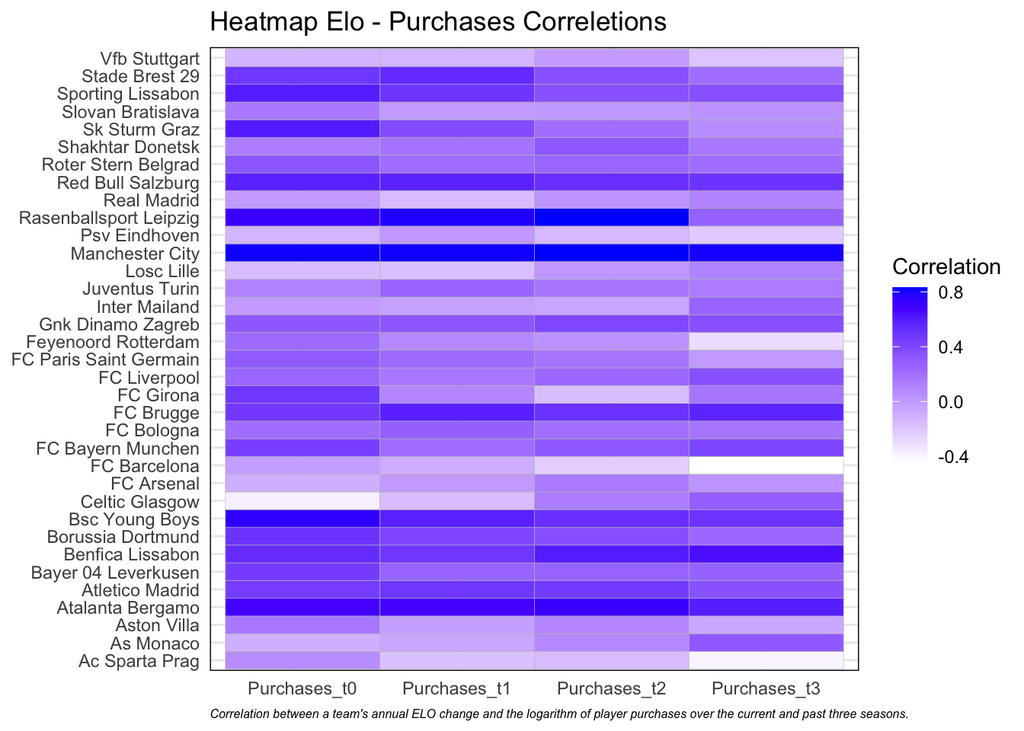

```r
#Heatmap Plot

heatmap <- ggplot(correlations, aes(x = Lag, y = Team, fill = Correlation)) +
  geom_tile(color = "gray") +
  scale_fill_gradient(low="white", high="blue") +
  theme_minimal() +
  theme(
    plot.caption = element_text(hjust = 0, face = "italic", size = 6),
    panel.border = element_rect(color = "black", fill = NA, size = 0.5)
  ) +
  labs(
    title = "Heatmap Elo - Purchases Correletions",
    x = NULL,
    y = NULL,
    fill = "Correlation",
    caption = "Correlation between a team's annual ELO change and the logarithm of player purchases over the current and past three seasons."
  )

heatmap
```

```r
ggsave("outputs/heatmap.jpg", plot = heatmap)
```

This heat-map shows that the correlation between purchases and performance varies widely among teams. For example, Manchester City and Leipzig show a strong correlation, while Celtic and Barcelona do not. This may indicates that other factors, such as playing style, youth player strength, or the quality of new signings, may need to be considered.

### 6.Data Management and Reproducibility

````r
rmd_file <- "MY472-AT24-final-report.Rmd"

read_file(rmd_file) %>% # read the file as a text file
  str_squish() %>% # remove all extra white space
  str_replace("^.+?output.+?[-]{3}", "") %>% # remove header
  str_replace_all("``` *[{].+?```", " ") %>% # remove code chunks
  str_replace_all("<![-].+?-->", " ") %>% # remove rmd comments
  str_replace_all("[!]?\\[.+?\\][(].+?[)]", " ") %>% # remove links
  str_replace_all("(^|\\s+)[^A-Za-z0-9]+", " ") %>% # remove symbols (1)
  str_replace_all("[^A-Za-z0-9]+($|\\s+)", " ") %>% # remove symbols (2)
  str_count("\\S+") %>%
  paste("The document is", ., "words.") %>%
  print()
````

```
## [1] "The document is 983 words."
```